# Econ144_hw5

Sijia Hua

6/3/2019

```r
library("readxl")
library(forecast)
library(tseries)
library("TSA")
library("fpp2")
library(MLmetrics) # use RMSE
library(dplyr)
```

```r
library(ggplot2)
library(AnalyzeTS)
library(Hmisc)
```

1. Problem 7.8 (i.e., Chapter 7, Problem 8) from Textbookc. Recall your retail time series data (from Exercise 3 in Section 2.10). (1)Why is multiplicative seasonality necessary for this series?

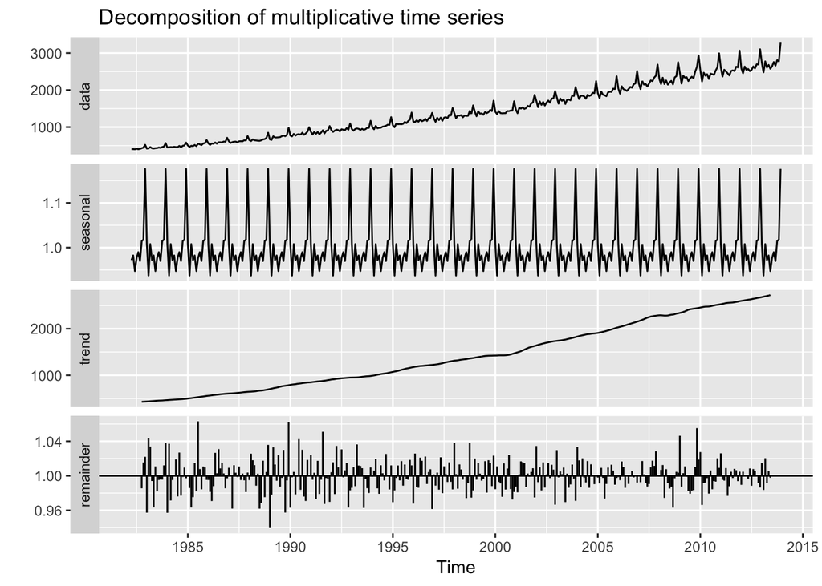

```r
setwd("/Users/Renaissance/Desktop")
retaildata <- readxl::read_excel("retail.xlsx", skip = 1)
ts_food <- ts(retaildata[,"A3349398A"],frequency=12, start=c(1982,4))

ts_food %>% decompose(type="multiplicative") %>%autoplot()
```

Yes, multiplicative seasonality is necessary. There are obvious seasonal factors. (2)Apply Holt-Winters’ multiplicative method to the data. Experiment with making the trend damped.

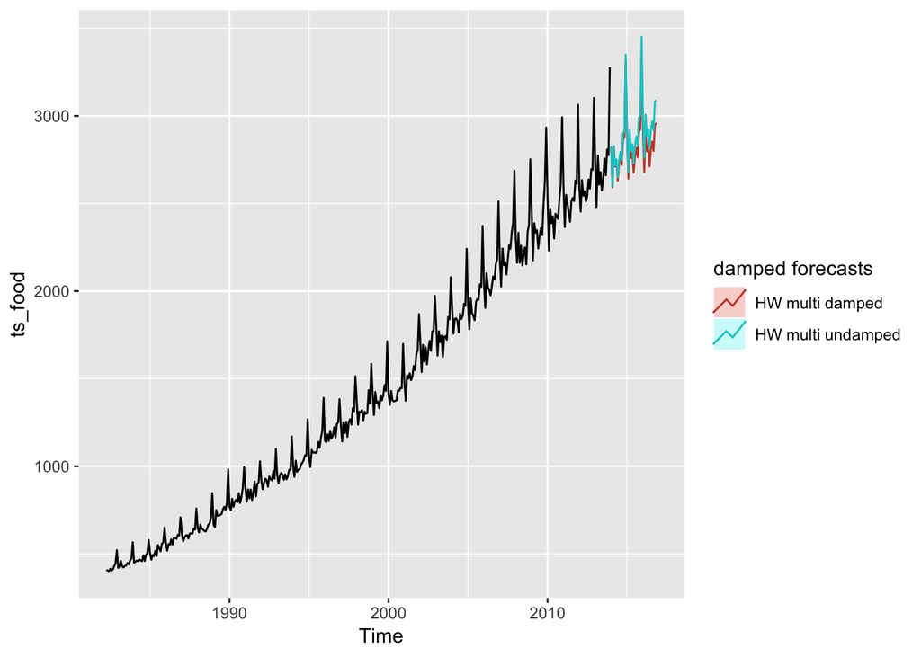

```r
# use Holt-Winters with forecast 35 steps
fit_food <- hw(ts_food, damped = TRUE, seasonal = "multiplicative", h = 35)
fit_undamp <- hw(ts_food, damped = FALSE, seasonal = "multiplicative", h = 35)
autoplot(ts_food) +
  autolayer(fit_food, series = "HW multi damped", PI = FALSE)+
  autolayer(fit_undamp, series = "HW multi undamped", PI = FALSE)+
  guides(colour=guide_legend(title="damped forecasts"))
```

(3)Compare the RMSE of the one-step forecasts from the two methods. Which do you prefer?

```r
damp_onestep <- hw(ts_food, damped = TRUE, seasonal = "multiplicative", h = 1)
undamp_onestep <- hw(ts_food, damped = FALSE, seasonal = "multiplicative", h = 1)
accuracy(damp_onestep)
```

```
##                    ME     RMSE      MAE       MPE     MAPE     MASE
## Training set 4.244765 29.63087 22.26018 0.2959731 1.785469 0.292681
##                    ACF1
## Training set -0.2184672
```

```r
accuracy(undamp_onestep)
```

```
##                    ME     RMSE      MAE       MPE     MAPE      MASE
## Training set 1.496135 29.43051 22.25676 0.1603693 1.799731 0.2926361
##                    ACF1
## Training set -0.0300701
```

RMSE of damped is 29.63 RMSE of undamped is 29.43. Hence, from RMSE, undamped works better.

(4)Check that the residuals from the best method look like white noise.

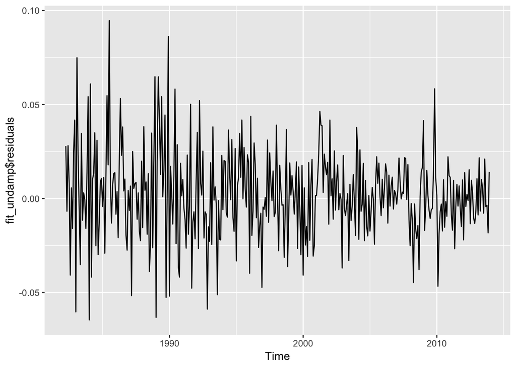

```r
autoplot(fit_undamp$residuals) #which looks like white noise
```

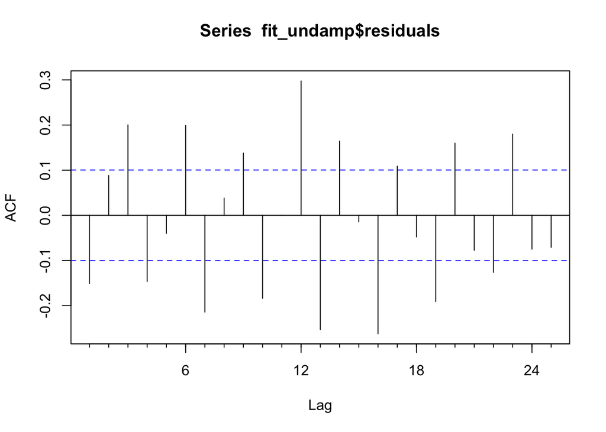

```r
# check for acf
Acf(fit_undamp$residuals)
```

Residual of the best method looks like white noise, but the magnitude before 2000 seems bigger than that after 2000. After checking Acf, it is not a white noise. (5)Now find the test set RMSE, while training the model to the end of 2010. Can you beat the seasonal naïve approach from Exercise 8 in Section 3.7?

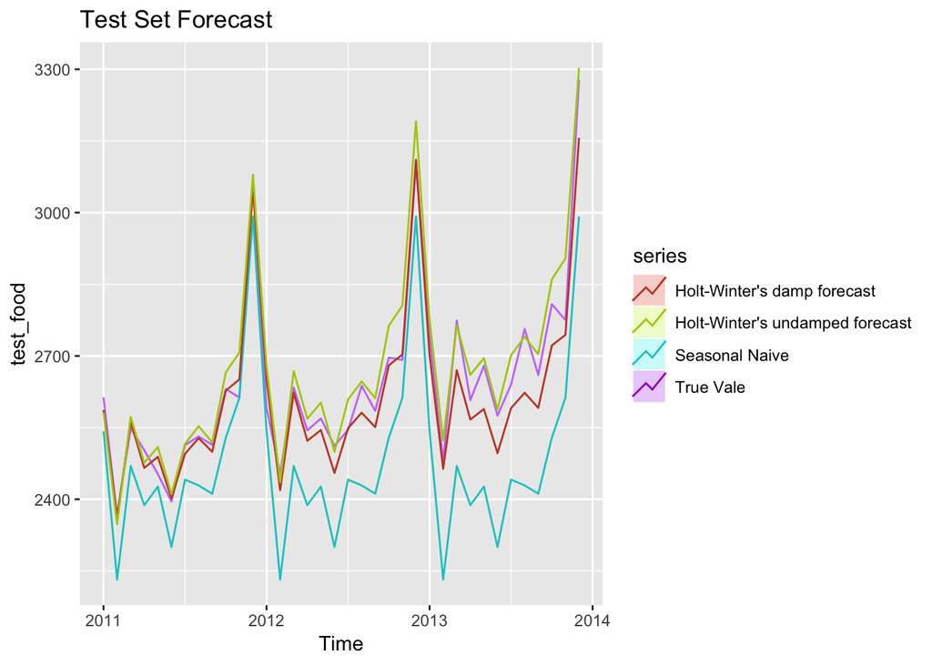

```r
# set up train set and test set
train_food <- window(ts_food, end = c(2010, 12))
test_food <- window(ts_food, start = c(2011, 1))
# three forecast methods of training set
snaive_train <- snaive(train_food, h = 36)
damp_train <- hw(train_food, damped = TRUE, seasonal = "multiplicative", h = 36)
undamp_train <- hw(train_food, damped = FALSE, seasonal = "multiplicative", h = 36)

autoplot(test_food, series = "True Vale") +
  autolayer(snaive_train, series = "Seasonal Naive", PI = FALSE) +
  autolayer(damp_train, series = "Holt-Winter's damp forecast", PI = FALSE) +
  autolayer(undamp_train, series = "Holt-Winter's undamped forecast", PI = FALSE) +
  ggtitle ('Test Set Forecast')
```

```r
RMSE(test_food, snaive_train$mean)
```

```
## [1] 180.1991
```

```r
RMSE(test_food, damp_train$mean)
```

```
## [1] 51.78368
```

```r
RMSE(test_food, undamp_train$mean)
```

```
## [1] 50.04274
```

By comparing, Undamped Holt-Winter multiplicative process gives a better approximation. It beats the seasonal naive approach.

2. Problem 7.10 (i.e., Chapter 7, Problem 10) from Textbookc. (1)For this exercise use data set ukcars, the quarterly UK passenger vehicle production data from 1977Q1–2005Q1. Plot the data and describe the main features of the series.

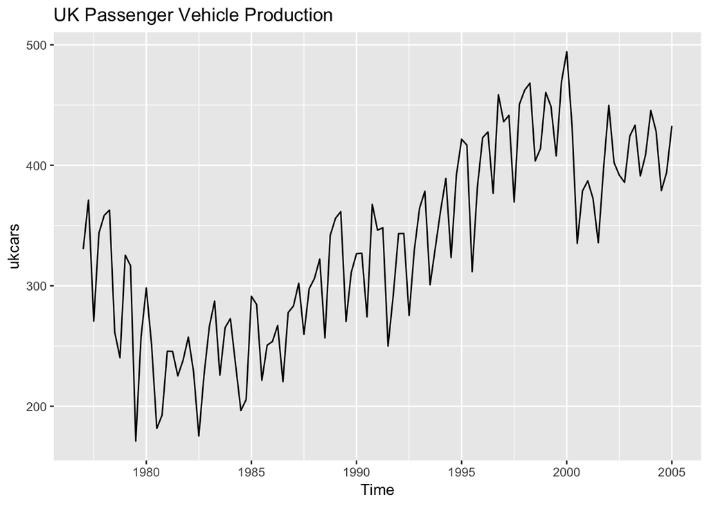

```r
autoplot(ukcars) +
  ggtitle("UK Passenger Vehicle Production")
```

There is a decreasing trend before 1980, followed by a continuously increasing trend to 2000. From 2000 to 2005, some fluctuations appear. This data set has strong seasonal factors.

(2)Decompose the series using STL and obtain the seasonally adjusted data.

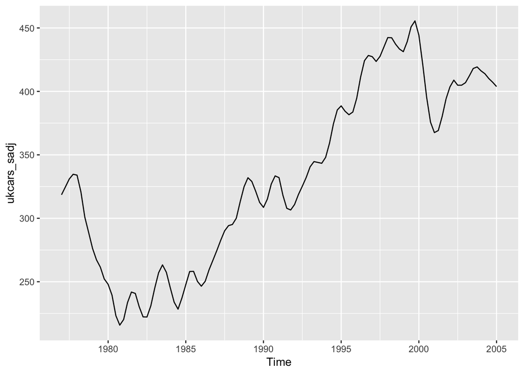

```r
stl_ukcars <- stl(ukcars, s.window = "periodic")
ukcars_sadj <- stl_ukcars$time.series[,2]
autoplot(ukcars_sadj) # after seasonal adjusted
```

(3)Forecast the next two years of the series using an additive damped trend method applied to the seasonally adjusted data. (This can be done in one step using stlf() with arguments etsmodel=“AAN”, damped=TRUE.)

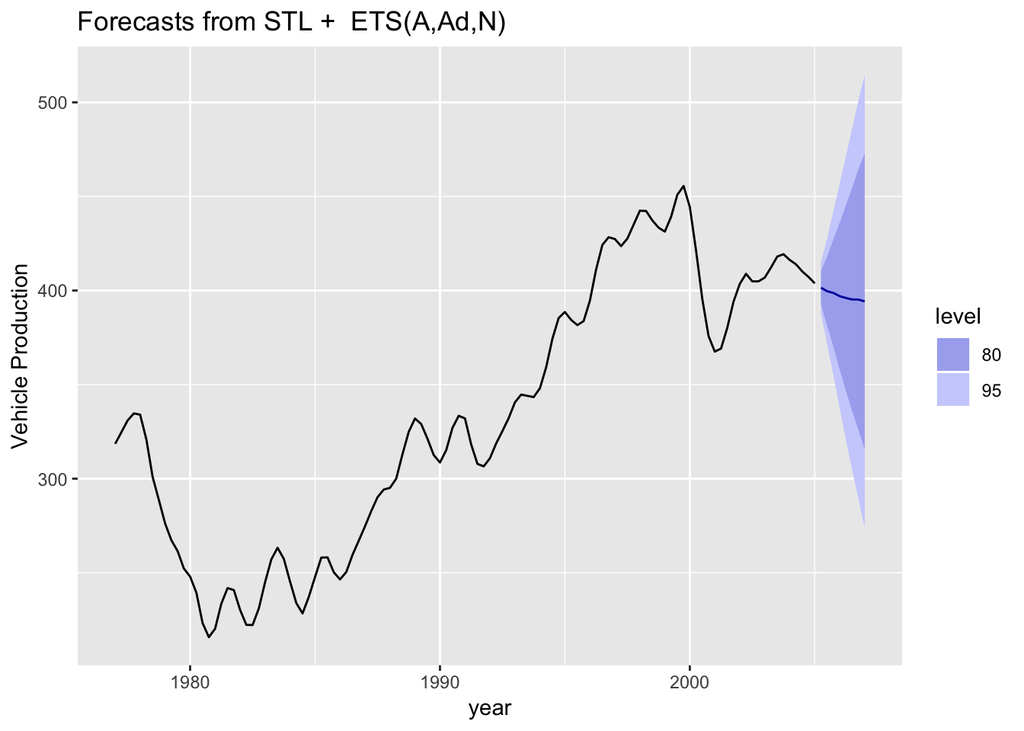

```r
pred_sadj <- stlf(ukcars_sadj, etsmodel = "AAN", damped = TRUE, h = 8)

autoplot(pred_sadj) +
  xlab("year") +
  ylab("Vehicle Production")
```

(4)Forecast the next two years of the series using Holt’s linear method applied to the seasonally adjusted data (as before but with damped=FALSE).

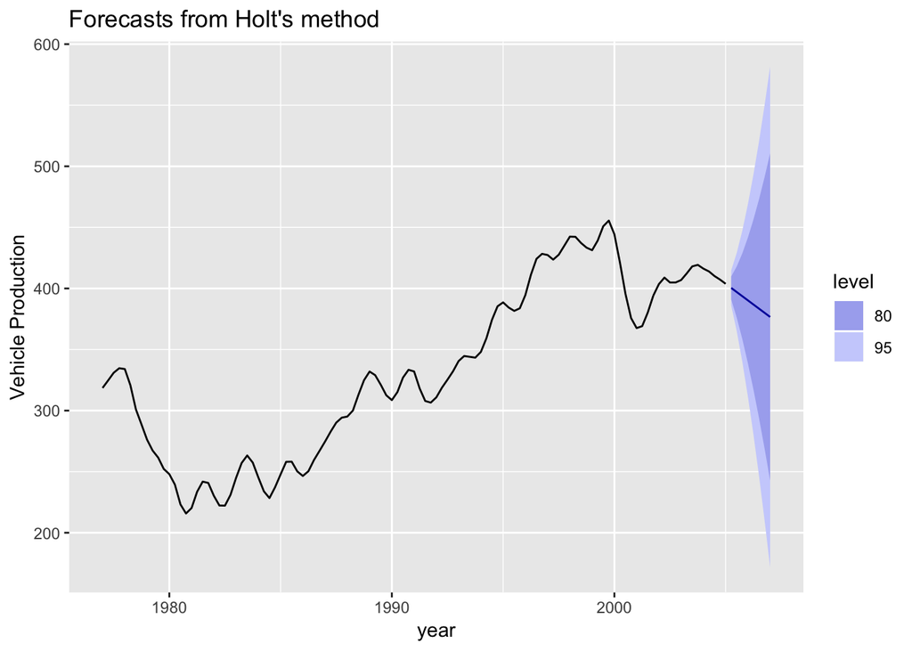

```r
hw_uk <- holt(ukcars_sadj, h = 8, damped=FALSE)
autoplot(hw_uk) +
  xlab("year") +
  ylab("Vehicle Production")
```

(5)Now use ets() to choose a seasonal model for the data.

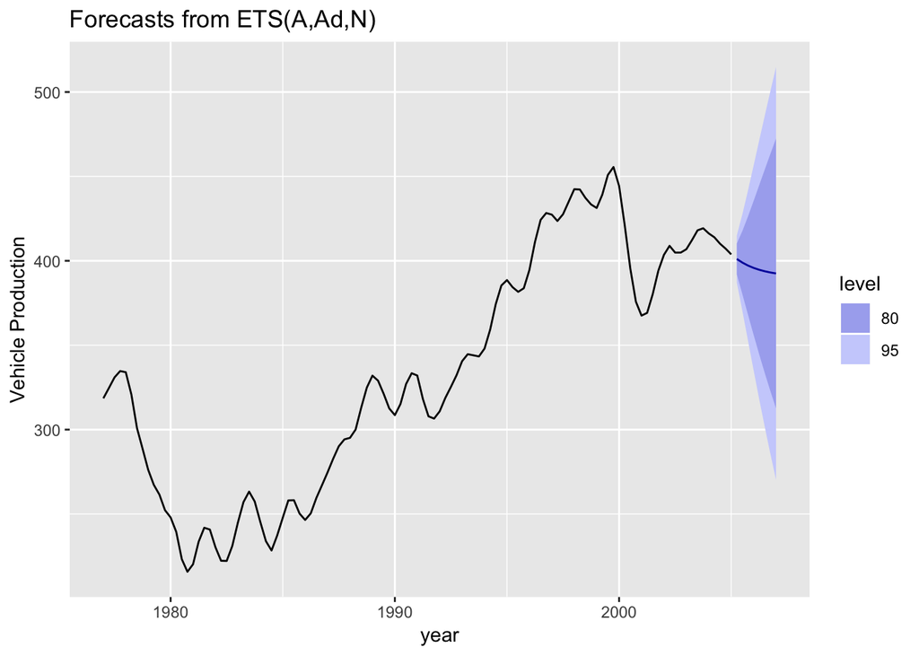

```r
ukcars_sadj %>% forecast(h = 8) %>%
  autoplot() +
  xlab("year") +
  ylab("Vehicle Production")
```

(6)Compare the RMSE of the ETS model with the RMSE of the models you obtained using STL decompositions. Which gives the better in-sample fits?

```r
ets_uk <- forecast(ukcars_sadj, h = 8) # by ets

RMSE(pred_sadj$fitted, ukcars_sadj) # 6.86 by stlf
```

```
## [1] 6.860955
```

```r
RMSE(ets_uk$fitted, ukcars_sadj) # 6.96 by ets
```

```
## [1] 6.96362
```

By compring RMSE, stl gives a better in-sample fits.

(7)Compare the forecasts from the three approaches? Which seems most reasonable? Check the residuals of your preferred model.

```r
# check for accuracy
accuracy(pred_sadj)
```

```
##                     ME     RMSE      MAE        MPE     MAPE     MASE
## Training set 0.1087044 6.860955 5.134386 0.06791621 1.640731 0.235849
##                   ACF1
## Training set 0.2622221
```

```r
accuracy(ets_uk)
```

```
##                    ME    RMSE      MAE        MPE     MAPE      MASE
## Training set 0.109292 6.96362 5.210045 0.06815573 1.665793 0.2393244
##                   ACF1
## Training set 0.2362471
```

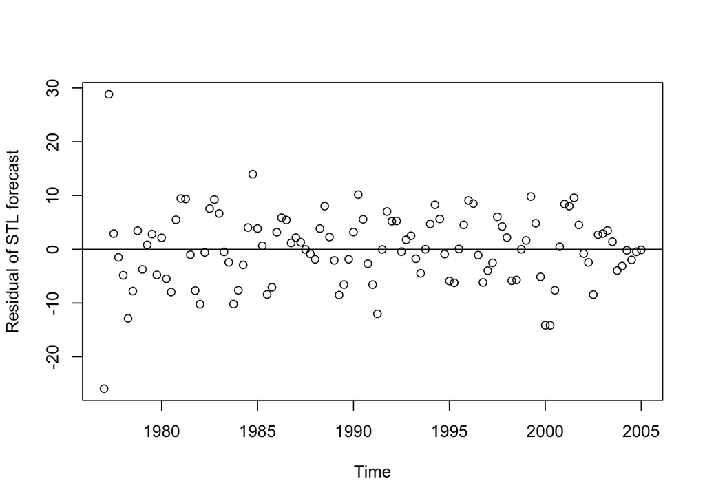

```r
# check the residual of stl
plot(pred_sadj$residuals, type = "p", ylab = "Residual of STL forecast")
abline(a = 0, b = 0)
```

By obsering the graphs, stl and ets gives more reasonable forecasts, since they are relatively smoother than the prediciton by Holt’s linear. Holt’s linear’s prediction seems a stright linear line without considering trend. After comparing the RMSE, ME, MAE of stl and ets, stl is preferred. The residual plot of stl is randomly distributed and bounce between the line y = 0, with two outliers located at the top left and bottom left of the residual plot. Hence, we can say stl is an appropriate fit model for uk vehicle productions time series.

3. (a)Update the time series of the SP500 index in Section 14.1 and comment on the volatility of recent times compared to that of past times.

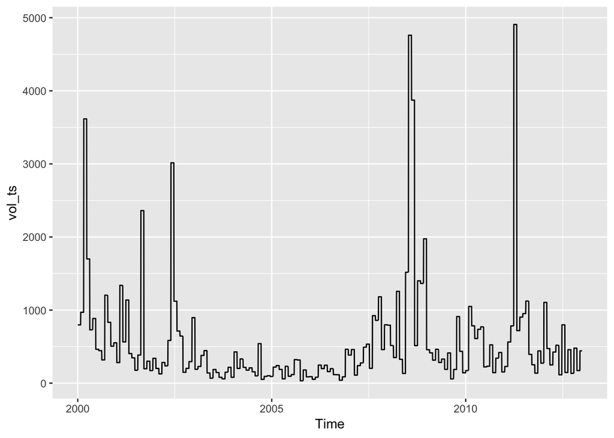

```r
setwd("/Users/Renaissance/Desktop")
sp500 <- read_xls("hw5_14a.xls")
# I choose to use close price of sp500
# extract close and open price
sp500_close <- sp500[, c("Close")]
sp500_open <- sp500[, c("Open")]
# calculate volatility
# I set the window to 20 days
n <- dim(sp500)[1]
num_window  <- floor(n/ 20) # how many sets have 20 days
last_size <- dim(sp500)[1] %% 20 # the size of last set
vol_sp500 <- data.frame(vector(mode = "numeric", length = n))
colnames(vol_sp500) <- c("volatility")

for (i in 1: num_window){
  subset <- sp500_close[(20*(i-1)+1):(20*i),]
  mean_20 <- mean(unlist(subset))
  std_20 <- sd(unlist(subset))
  vol <- sum( (subset - mean_20)^2)/ 20
  vol_sp500[(20*(i-1)+1):(20*i), ] <- vol
}

subset <- sp500_close[(num_window*20+1):n, ]
mean_20 <- mean(unlist(subset))
std_20 <- sd(unlist(subset))
vol <- sum( (subset - mean_20)^2)/ last_size
vol_sp500[(num_window*20+1):n, ] <- vol

vol_ts <- ts(vol_sp500, 2000, 2013, frequency = 258)
autoplot(vol_ts)
```

```r
# Comment: By observing Volatility in recent years is more volatile than past.
```

Comment: By observing Volatility graph in recent years, is more volatile than past.

3.(b)Compute the autocorrelation functions of returns and squared returns.

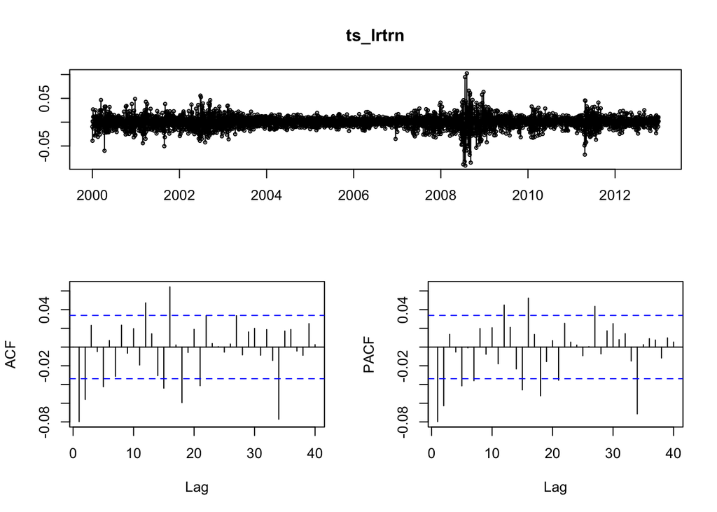

```r
##calcualte log returns
sp500_lrtrn <- log(sp500_close/ sp500_open)
ts_lrtrn <- ts(sp500_lrtrn, 2000, 2013, frequency = 258)
tsdisplay(ts_lrtrn, lag.max = 40)
```

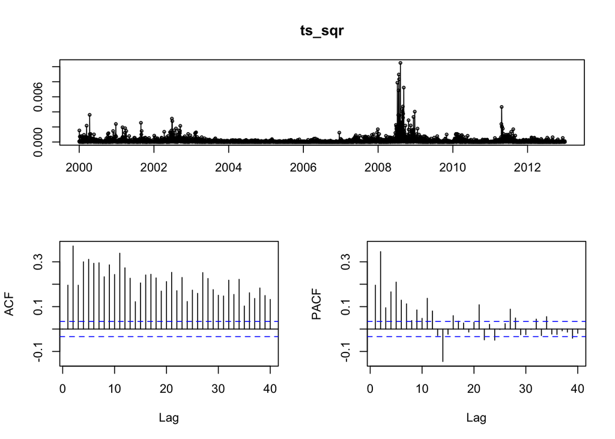

```r
##calculate square returns
sp500_sqr <- sp500_lrtrn^2
ts_sqr <- ts(sp500_sqr, 2000, 2013, frequency = 258)
tsdisplay(ts_sqr, lag.max = 40)
```

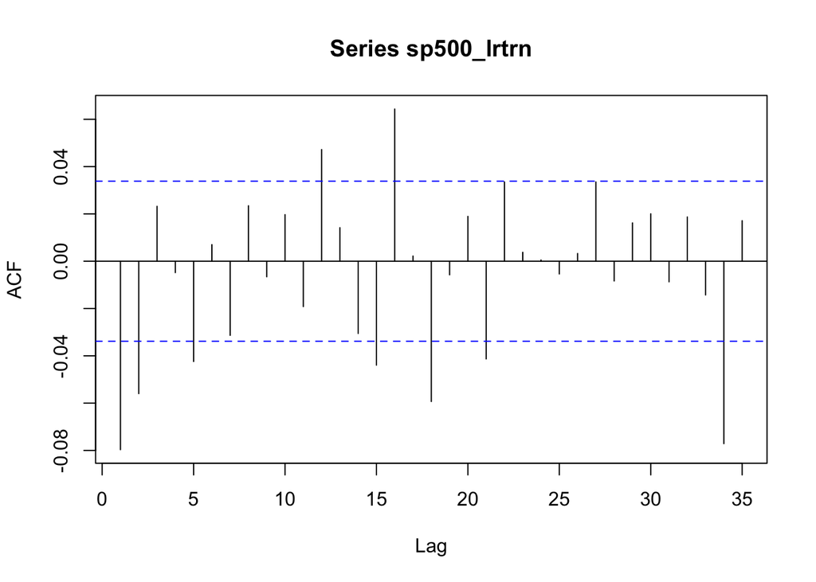

```r
acf(sp500_lrtrn)
```

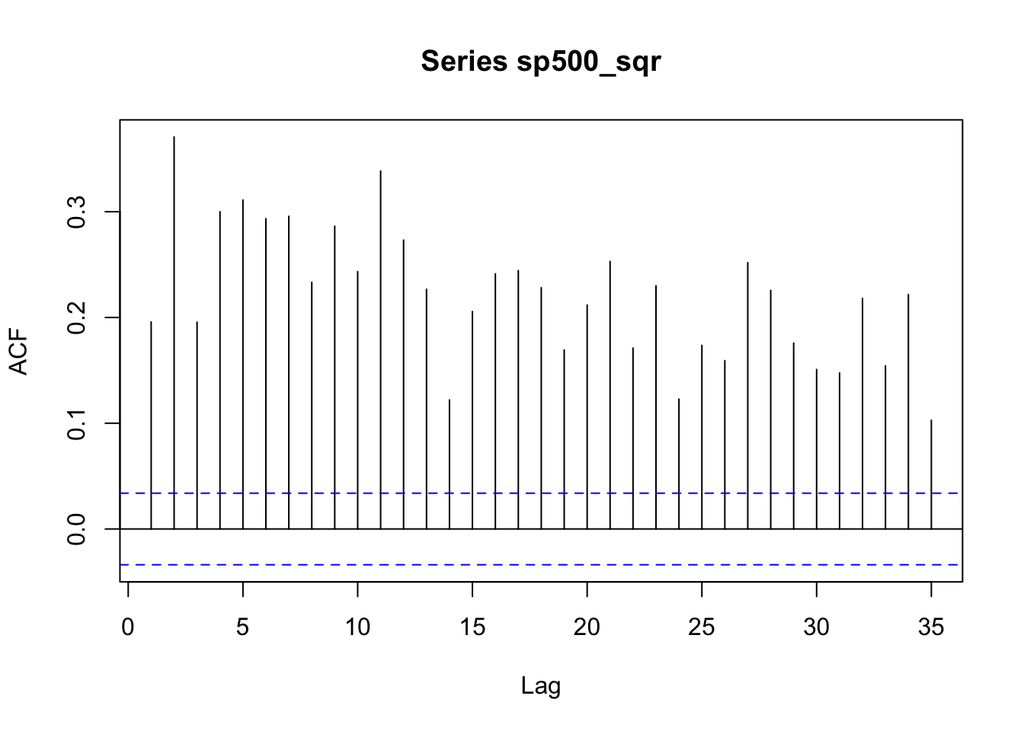

```r
acf(sp500_sqr)
```

There are signal of seasonality in the return and squared return. All acf values are significant in tbe acf of squared return.